Project 1

Smirnov Viktor https://github.com/Smirness

11/23/2022

# Introduction

There are tables in archive. Access via link: https://stepik.org/media/attachments/lesson/603865/athlete_events.zip. It’s including 12 files with csv format.

```python
from zipfile import ZipFile
import pandas as pd
```

```python
from zipfile import ZipFile

file = "C:/Users/Viktor/BI_Stat_2022/olimpic_games/data/athlete_events.zip"
# opening the zip file in READ mode
with ZipFile(file, 'r') as zip:
    zip.printdir()
```

```
## File Name                                             Modified             Size
## athlete_events00.csv                           2021-10-18 18:53:30      2992729
## athlete_events01.csv                           2021-10-18 18:53:22      2992655
## athlete_events02.csv                           2021-10-18 18:51:06      2992674
## athlete_events03.csv                           2021-10-18 18:53:16      2992639
## athlete_events04.csv                           2021-10-18 18:52:58      2992651
## athlete_events05.csv                           2021-10-18 18:53:08      2992706
## athlete_events06.csv                           2021-10-18 18:52:48      2992619
## athlete_events07.csv                           2021-10-18 18:48:34      2992729
## athlete_events08.csv                           2021-10-22 01:03:58      2992592
## athlete_events09.csv                           2021-10-18 18:52:08      2992695
## athlete_events10.csv                           2021-10-18 18:51:52      2992621
## athlete_events11.csv                           2021-10-18 18:51:38      2992598
```

# Task 1

The data are divided into several files. The function **merger()** combines the observations into a single table.

Syntaxis the function:  
`merger(zipfile, file_type, save_type, path_output, name_output)`  
Default command for merging tables from zip file `merger("C:/Users/Viktor/BI_Stat_2021/olimpic_games/data/athlete_events.zip", "csv")`

```python
def merger(zipfile, file_type, save_type="csv", path_output="Default", name_output="Default"):
    """
    This function merging into one data frame several files that are compressed into one zip file.
    :param zipfile: path to zip file with table datas
    :param file_type: file type of table datas. Accepting csv or excel.
    :param save_type: file type for merged table. Default is csv.
    :param path_output: path for saving merged table.
                        Default save in folder where is zipfile.
    :param name_output: name for saved merged table.
                        Default saving as zipfile name.
    :return file: saved merged table.
    """
    # for opening multiple file types
    ft_read = dict(csv=pd.read_csv, excel=pd.read_excel)
    ft_write = dict(csv="to_csv", excel="to_excel")

    pd_file_type = ft_read[file_type]
    ft_write_type = ft_write[save_type]

    # if path_output is Default, then saving in folder with zipfile
    if path_output == "Default":
        path_output = zipfile.split(sep="/")
        path_output = '/'.join(map(str, path_output[:-1]))

    # if name_output is Default, then saving as name of zipfile
    if name_output == "Default":
        path_file = zipfile.split(sep="/")
        name_output = path_file[-1].split(sep=".")[0]

    # merging into one data frame several files that are compressed into one zip file
    df = pd.concat(
        [pd_file_type(ZipFile(zipfile).open(i)) for i in ZipFile(zipfile).namelist()],
        ignore_index=True
    )
    getattr(df, ft_write_type)(path_output + "/" + name_output + "." + save_type)
```

**Ans 1 there is the function merging into one data frame several files that are compressed into one zip file.**

# Task 2

See if all the data is really correct? If you find something wrong If you find something wrong, please correct it. Explain why you used this approach. Maybe it has alternatives?

```python
df = pd.read_csv("C:/Users/Viktor/BI_Stat_2022/olimpic_games/data/athlete_events.csv")
```

```python
df.shape
```

```
## (271115, 16)
```

```python
df.dtypes
```

```
## Unnamed: 0      int64
## ID              int64
## Name           object
## Sex            object
## Age           float64
## Height        float64
## Weight        float64
## Team           object
## NOC            object
## Games          object
## Year          float64
## Season         object
## City           object
## Sport          object
## Event          object
## Medal          object
## dtype: object
```

There is 15 parameters. ‘Unnamed: 0’ is string number. So let’s remove this one.

```python
df.drop("Unnamed: 0", axis=1, inplace = True)
df.dtypes
```

```
## ID          int64
## Name       object
## Sex        object
## Age       float64
## Height    float64
## Weight    float64
## Team       object
## NOC        object
## Games      object
## Year      float64
## Season     object
## City       object
## Sport      object
## Event      object
## Medal      object
## dtype: object
```

The dataset has the following features:

- ID – Unique number for each athlete
- Name – Athlete’s name
- Sex – M or F
- Age – Integer
- Height – In centimeters
- Weight – In kilograms
- Team – Team name
- NOC – National Olympic Committee 3-letter code
- Games – Year and season
- Year – Integer
- Season – Summer or Winter
- City – Host city
- Sport – Sport
- Event – Event
- Medal – Gold, Silver, Bronze, or NA

## Missing values

```python
df.isna().sum()
```

```
## ID             0
## Name           1
## Sex            2
## Age         9476
## Height     60172
## Weight     62876
## Team           3
## NOC            4
## Games          5
## Year           7
## Season         7
## City           7
## Sport          7
## Event          8
## Medal     231333
## dtype: int64
```

An important parameter of this dataframe is the name. Without a name it is impossible to identify the participant. No name = no participant. Delete. The remaining lines that have nan left. But be careful when processing the data.

```python
df = df.dropna(axis = 0, subset=["Name"])
df.isna().sum()
```

```
## ID             0
## Name           0
## Sex            1
## Age         9475
## Height     60171
## Weight     62875
## Team           2
## NOC            3
## Games          4
## Year           6
## Season         6
## City           6
## Sport          6
## Event          7
## Medal     231332
## dtype: int64
```

## Data in wrong format

```python
df.dtypes
```

```
## ID          int64
## Name       object
## Sex        object
## Age       float64
## Height    float64
## Weight    float64
## Team       object
## NOC        object
## Games      object
## Year      float64
## Season     object
## City       object
## Sport      object
## Event      object
## Medal      object
## dtype: object
```

Let’s rewrite data types

```python
for param in ['Age', 'Height', 'Year']:
  df[param] = df[param].astype('Int64')
```

## Checking unique names of parametes

```python
df.columns
```

```
## Index(['ID', 'Name', 'Sex', 'Age', 'Height', 'Weight', 'Team', 'NOC', 'Games',
##        'Year', 'Season', 'City', 'Sport', 'Event', 'Medal'],
##       dtype='object')
```

```python
df.Sex.unique()
```

```
## array(['M', 'F', 'G', nan], dtype=object)
```

```python
df.Season.unique()
```

```
## array(['Summer', 'Winter', nan], dtype=object)
```

There is unexpected G sex. Let’s see who is it.

```python
import numpy as np
df.index[df['Sex'] == 'G'].tolist()
```

```
## [158593, 158625]
```

```python
print(df.loc[158593]) # Participant is Man. His name is Pavel Mike.
```

```
## ID                          79609
## Name                   Pavel Mike
## Sex                             G
## Age                            22
## Height                        182
## Weight                       79.0
## Team               Czechoslovakia
## NOC                           TCH
## Games                 1972 Summer
## Year                         1972
## Season                     Summer
## City                       Munich
## Sport                    Handball
## Event     Handball Men's Handball
## Medal                      Silver
## Name: 158593, dtype: object
```

```python
print(df.loc[158625]) # Participant is Man. His name is Anatoly Mikhaylin.

# rewrite their sex as M
```

```
## ID                                    79630
## Name                      Anatoly Mikhaylin
## Sex                                       G
## Age                                      37
## Height                                 <NA>
## Weight                                  NaN
## Team                                 Russia
## NOC                                     RUS
## Games                           1996 Summer
## Year                                   1996
## Season                               Summer
## City                                Atlanta
## Sport                               Sailing
## Event     Sailing Mixed Two Person Keelboat
## Medal                                   NaN
## Name: 158625, dtype: object
```

```python
df.Sex.loc[158593] = 'M'
df.Sex.loc[158625] = 'M'
```

## Duplicated records

```python
all_columns = ['ID', 'Name', 'Sex', 'Age', 'Height', 'Weight', 'Team', 'NOC', 'Games', 'Year', 'Season', 'City', 'Sport', 'Event', 'Medal']
```

```python
df_dupl = df[df.duplicated(subset=all_columns, keep= False)]
df_dupl.shape
```

```
## (1997, 15)
```

1997 lines are duplicates. Let’s get rid of them.

```python
print("Before dropping",df.shape)
```

```
## Before dropping (271114, 15)
```

```python
df.drop_duplicates(subset=all_columns, keep='first', inplace=True)
print("After dropping",df.shape)
```

```
## After dropping (269729, 15)
```

Checking

```python
df_dupl = df[df.duplicated(subset=all_columns, keep= False)]
df_dupl.shape
```

```
## (0, 15)
```

There are no duplicates. Now the dataframe is ready for working.

## Statistical summary. Wrong Data.

We selected the parameters that are available for statistical analysis.

```python
stat_columns = ['Age', 'Height', 'Weight', 'Year']
```

```python
df[stat_columns].describe(percentiles = [0.01,0.99])
```

```
##              Age      Height         Weight         Year
## count   260413.0    210915.0  208202.000000     269723.0
## mean   25.455549  175.339743      70.701617  1978.622913
## std     6.178193   10.524665      14.349885    29.751999
## min         10.0       127.0       7.000000       1896.0
## 1%          15.0       150.0      43.000000       1904.0
## 50%         24.0       175.0      70.000000       1988.0
## 99%         47.0       200.0     114.000000       2016.0
## max        240.0       340.0     214.000000       2016.0
```

There is unexpected values as max-age, max-height, min-weight. It’s look like unreal human parameters. Lets’ rewrite these errors on actual value or as NaN

```python
import numpy as np
df.index[df['Age'] == 240].tolist()
```

```
## [45461]
```

```python
print(df.loc[45461])
```

```
## ID                                         23459
## Name                  Flicien Jules mile Courbet
## Sex                                            M
## Age                                          240
## Height                                      <NA>
## Weight                                       NaN
## Team                                     Belgium
## NOC                                          BEL
## Games                                1912 Summer
## Year                                        1912
## Season                                    Summer
## City                                   Stockholm
## Sport                                   Swimming
## Event     Swimming Men's 200 metres Breaststroke
## Medal                                        NaN
## Name: 45461, dtype: object
```

```python
df.Age.loc[45461] = 24 #out expactation is retyping 0. And the age is 24

df.index[df['Height'] == 340].tolist()
```

```
## [45650]
```

```python
print(df.loc[45650])
```

```
## ID                                                23549
## Name                    Kirsty Leigh Coventry (-Seward)
## Sex                                                   F
## Age                                                  28
## Height                                              340
## Weight                                             64.0
## Team                                           Zimbabwe
## NOC                                                 ZIM
## Games                                       2012 Summer
## Year                                               2012
## Season                                           Summer
## City                                             London
## Sport                                          Swimming
## Event     Swimming Women's 200 metres Individual Medley
## Medal                                               NaN
## Name: 45650, dtype: object
```

```python
df.Height.loc[45650] = 176 # Her Height is 176 cm, not 340.

df.index[df['Weight'] == 7].tolist()
```

```
## [135885]
```

```python
print(df.loc[135885])
```

```
## ID                 68370
## Name      Helmut Lehmann
## Sex                    M
## Age                   25
## Height               178
## Weight               7.0
## Team                 NaN
## NOC                  NaN
## Games                NaN
## Year                <NA>
## Season               NaN
## City                 NaN
## Sport                NaN
## Event                NaN
## Medal                NaN
## Name: 135885, dtype: object
```

```python
df.Weight.loc[135885] = np.nan
```

Keeping fixed dataframe:

```python
df.to_csv("C:/Users/Viktor/BI_Stat_2022/olimpic_games/data/athlete_events_fixed.csv")
```

**Ans 2 we got fixed table**

# Task 3

Find out the age of the youngest athletes of both sexes at the 1992 Olympics.

```python
df_1992 = df.query("Year == 1992")
df_1992_M = df_1992.query('Sex == "M"')
df_1992_F = df_1992.query('Sex == "F"')
print("The age of the youngest male athlete is",df_1992_M.Age.min())
```

```
## The age of the youngest male athlete is 11
```

```python
print("The age of the youngest female athlete is",df_1992_F.Age.min())
```

```
## The age of the youngest female athlete is 12
```

**Answ 3 At the 1992 Olympics the age of the youngest male athlete is 11 and the female athlete is 12.**

# Task 4

Mean and SD of the Height variable Calculate the mean and standard deviation of the Height variable for athletes of each sex.

```python
df_M = df.query('Sex == "M"')
df_F = df.query('Sex == "F"')
mean_Height_M = round(df_M.Height.mean(skipna=True), 2)
mean_Height_F = round(df_F.Height.mean(skipna=True), 2)
SD_Height_M = round(df_M.Height.std(skipna=True), 2)
SD_Height_F = round(df_F.Height.std(skipna=True), 2)
```

```python
table_t4 = pd.DataFrame([('Male', mean_Height_M, SD_Height_M),
                        ('Female', mean_Height_F, SD_Height_F)],
                        columns=('Sex', 'Mean', 'SD'))
print("Statistic about Height for both sex:", '\n', table_t4)
```

```
## Statistic about Height for both sex:
##        Sex    Mean    SD
## 0    Male  178.86  9.36
## 1  Female  167.84  8.78
```

**Ans 4 the table with calculated the mean and standard deviation of the Height variable for athletes of each sex:**

| Sex | **Mean** | **SD** |
| --- | --- | --- |
| **Male** | 178.86 | 9.36 |
| **Female** | 167.84 | 8.78 |

# Task 5

Calculate the mean value and standard deviation of the variable Height in tennis players (sex = F) at the 2000 Olympics. Round the answer to the first sign after the dot.

```python
df_F_Tenn_2000 = df.query('Sex == "F" and Sport == "Tennis" and Year == 2000')
Mean_Height_F_Tenn_2000 = round(df_F_Tenn_2000.Height.mean(skipna=True), 1)
SD_Height_F_Tenn_2000 = round(df_F_Tenn_2000.Height.std(skipna=True), 1)
print('The Height for tennis female player in 2000 is', '(',Mean_Height_F_Tenn_2000,'±',SD_Height_F_Tenn_2000,')','centimeters')
```

```
## The Height for tennis female player in 2000 is ( 171.8 ± 6.5 ) centimeters
```

# Task 6

In which sport was the heaviest athlete at the 2006 Olympics?

```python
df_2006 = df.query('Year == 2006')
heaviest_athlete_2006 = df_2006[df_2006['Weight'] == df_2006.Weight.max()]
print(heaviest_athlete_2006['Sport'])
```

```
## 8102    Skeleton
## Name: Sport, dtype: object
```

**Ans 6. The heaviest athlete at the 2006 Olympics participated in Skeleton sport.**

# Task 7

How many gold medals were won by women from 1980 to 2010 years?

```python
df_F_f80_t10_gold = df.query('Sex == "F" and 1980 <= Year <=2010 and Medal == "Gold"')
df_F_f80_t10_gold.shape
```

```
## (2249, 15)
```

**Ans 7 2249 gold medals were won by women from 1980 to 2010 years**

# Task 8

How many times has John Aalberg competed in the Olympics in different years?

```python
df.query('Name == "John Aalberg"').Year.unique
```

```
## <bound method Series.unique of 18    1992
## 19    1992
## 20    1992
## 21    1992
## 22    1994
## 23    1994
## 24    1994
## 25    1994
## Name: Year, dtype: Int64>
```

**Ans 8 John Aalberg participated two times in the Olympics in different years.**

# Task 9

Identify the least and most represented (by number of participants) age groups of athletes at the 2008 Olympic Games. Possible age groups: [15-25), [25-35), [35-45), [45-55].

```python
df_2008 = df.query('Year == 2008')
t9_inter = []
t9_quant = []

for i in range (10,100,5):
  t9_inter += [[i,i+4]]
  t9_quant += [len(df_2008.query('%d<Age<%d'%(i,i+10)))]

df_t9 = pd.DataFrame({
                      'interval': t9_inter,
                      'quantity': t9_quant
                        })
df_t9.drop(df_t9.index[df_t9.quantity == 0], inplace=True)
print(df_t9.query('quantity == quantity.min()'))
```

```
##     interval  quantity
## 11  [65, 69]         2
```

```python
print(df_t9.query('quantity == quantity.max()'))
```

```
##    interval  quantity
## 2  [20, 24]      8561
```

# Task 10

How different was the number of sports in the 2002 Olympics compared to the 1994 Olympics?

```python
df_num_sports_2008 = len(df.query('Year == 2008').Sport.unique())
df_num_sports_1994 = len(df.query('Year == 1994').Sport.unique())
dif_t10 = len(df.query('Year == 2008').Sport.unique()) - len(df.query('Year == 1994').Sport.unique())
print('In 1994 there were %d sports, and in 2008 there were %d. Over the years, the number of sports has increased by %d'%(df_num_sports_1994, df_num_sports_2008, dif_t10))
```

```
## In 1994 there were 12 sports, and in 2008 there were 34. Over the years, the number of sports has increased by 22
```

# Task 11

Print for the Winter and Summer Olympics separately the top 3 countries for each type of medals.

```python
def task_11(Season, Medal):
  """
  Print top 3 country with a medal in a season
  :param Season: Summer/Winter
  :param Medal: Gold/Bronze/Silver
  "return: list
  """
  Season, Medal # no idea why noting the parametes. It's needed.
  df_t11 = []
  df_t11_noc = []
  noc_top = []

  df_t11 = df.query('Season == %s and Medal == %s'%(Season, Medal)).groupby('NOC').groups

  for k, v in df_t11.items():
    df_t11_noc += [[k, len([item for item in v if item])]]

  df_t11_noc.sort(key = lambda x: x[1], reverse = True)

  for noc in df_t11_noc[0:3]:
    noc_top += [noc[0]]
  return noc_top
```

No idea at all how to fix code for using only one type ’ or ” when we call function. But it’s working. heh…

```python
table_t11 = pd.DataFrame(
  [('Summer', task_11('"Summer"', '"Gold"'), task_11('"Summer"', '"Silver"'), task_11('"Summer"', '"Bronze"')), ('Winter', task_11('"Winter"', '"Gold"'), task_11('"Winter"', '"Silver"'), task_11('"Winter"', '"Bronze"'))],
  columns=('Season', 'Gold', 'Silver', 'Bronze'))
print(table_t11)
```

```
##    Season             Gold           Silver           Bronze
## 0  Summer  [USA, URS, GBR]  [USA, GBR, URS]  [USA, GER, GBR]
## 1  Winter  [CAN, URS, USA]  [USA, CAN, NOR]  [FIN, SWE, USA]
```

**Ans 11 The table with top contries for each type of medals in both season.**

| **Season** | **Gold** | **Silver** | **Bronze** |
| --- | --- | --- | --- |
| **Summer** | USA, URS, GBR | USA, GBR, URS | USA, GER, GBR |
| **Winter** | CAN, URS, USA | USA, CAN, NOR | FIN, SWE, USA |

# Task 12

Create a new variable **Height_z_scores** and save the values of the **Height** variable after standardization.

```python
import scipy.stats as stats
import numpy as np

df_t12 = df
df_t12.insert(
        loc = 5,
        column = 'Height_z_scores',
        value = (df_t12.Height - df_t12.Height.mean())/df_t12.Height.std(ddof=0)
        )

print('Columns in new dataframe:\n', df_t12.columns)
```

```
## Columns in new dataframe:
##  Index(['ID', 'Name', 'Sex', 'Age', 'Height', 'Height_z_scores', 'Weight',
##        'Team', 'NOC', 'Games', 'Year', 'Season', 'City', 'Sport', 'Event',
##        'Medal'],
##       dtype='object')
```

```python
print('The first 3 values in new variable. Height_z_scores: \n',df_t12.Height_z_scores.head(3))
```

```
## The first 3 values in new variable. Height_z_scores:
##  0    0.443126
## 1   -0.507577
## 2        <NA>
## Name: Height_z_scores, dtype: Float64
```

**Ans 12 New variable ‘Height_z_scores’ is near ‘Height’.**

# Task 13

Optional: Create a new variable Height_min_max_scaled and save the values of the Height variable to it after applying the min-max normalization (you will need to figure out how it works). (2 points)

**Ans 13 the task skipped**

# Task 14

Compare the height, weight, and age of the men and women who participated in the Winter Olympic Winter Games. Please format the results so that we can immediately use them for the article. Bugs appear when creating graphs using Python in R-studio, so continue work with R language.

```r
r_df <- read.csv(("C:/Users/Viktor/BI_Stat_2022/olimpic_games/data/athlete_events_fixed.csv"))
```

```r
library(dplyr)
sex <- unlist(r_df %>% select(Sex))
height <- unlist(r_df %>% select(Height))
weight <- unlist(r_df %>% select(Weight))
age  <- unlist(r_df %>% select(Age))

t14_data = data.frame(sex, height, weight, age)
# drop rows with NA values
t14_data <- na.omit(t14_data)

head(t14_data)
```

```
##      sex height weight age
## Sex1   M    180     80  24
## Sex2   M    170     60  23
## Sex5   F    185     82  21
## Sex6   F    185     82  21
## Sex7   F    185     82  25
## Sex8   F    185     82  25
```

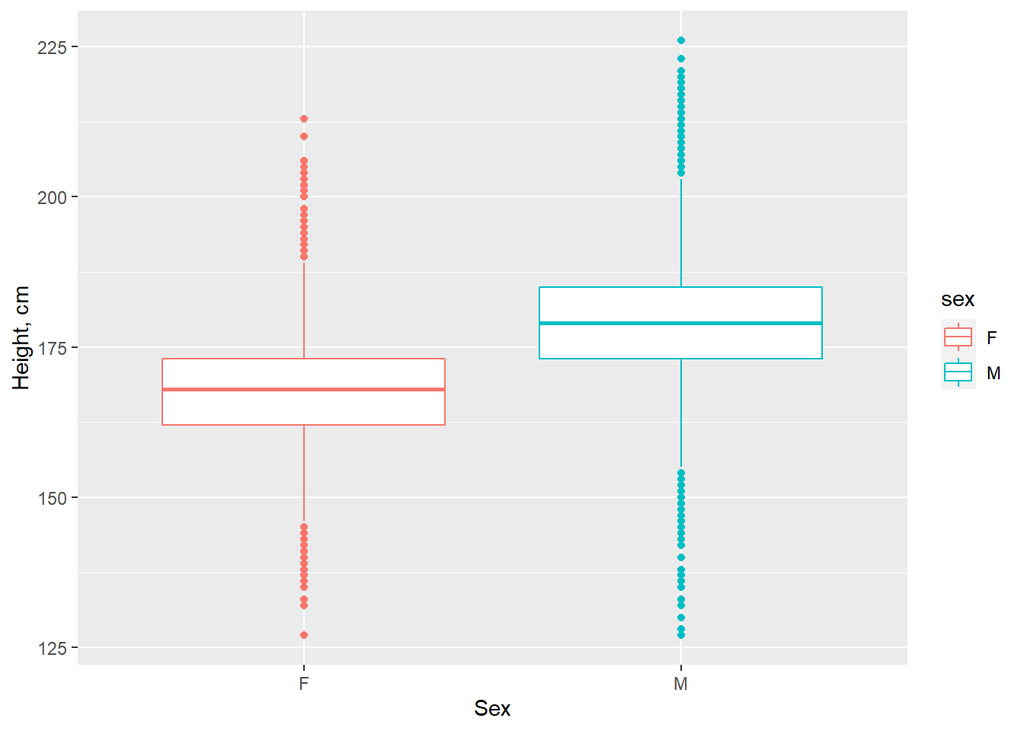

```r
library(ggplot2)

ggplot(t14_data, aes(x=sex, y=height, color=sex)) + geom_boxplot() + xlab('Sex') + ylab('Height, cm')
```

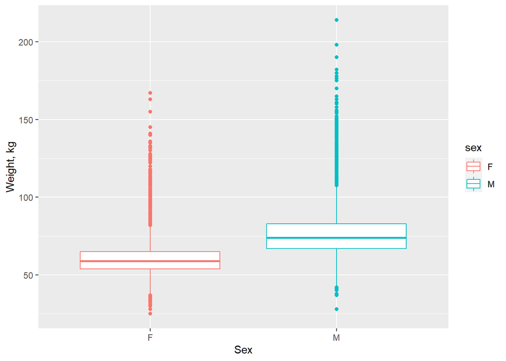

```r
ggplot(t14_data, aes(x=sex, y=weight, color=sex)) + geom_boxplot() + xlab('Sex') + ylab('Weight, kg')
```

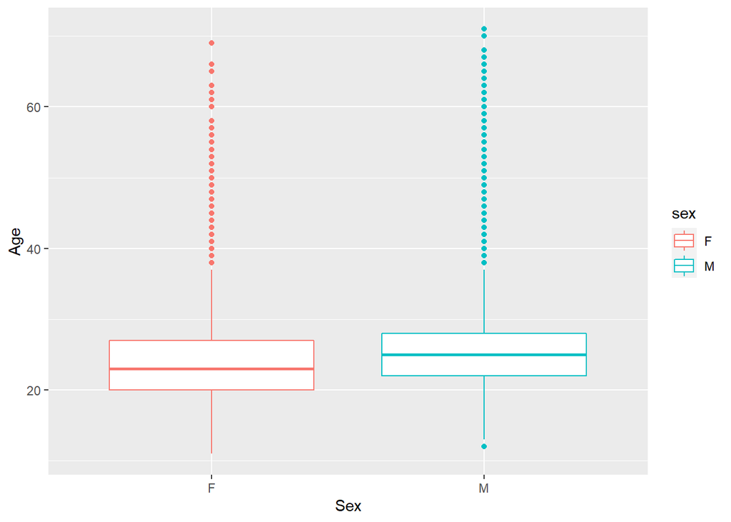

```r
ggplot(t14_data, aes(x=sex, y=age, color=sex)) + geom_boxplot()    + xlab('Sex') + ylab('Age')
```

**Ans 14 These pictures are available for download**

# Task 15

We are particularly interested in the Team and Medal variables. What can you tell us about them? what can you tell us about them? Do we have any reason to believe that they might be related? How did you determine that? The parameters “Team” and “Medal” can be interrelated. For example, a team contains strong participants who win a medal every year.

**Ans 15 the task skipped**